# Final Project

Andrew J Porter

Sept 16, 2019

## Weather Analysis in the United States

Below is a brief analysis of severe weather in the United States. The events are compared to each other on the basis on fatalies, injuries, property damage and crop damage.

```r
suppressWarnings({library(data.table)
library(dplyr)
library(formattable)
library(tidyr)
library(R.utils)
library(plyr)})
```

## Data Processing

```r
customRed = "#ff7f7f"
#url <- "https://d396qusza40orc.cloudfront.net/repdata%2Fdata%2FStormData.csv.bz2"
#download.file(url, "StormData.csv.bz2")
#library(R.utils)
#bunzip2("StormData.csv.bz2", "StormData.csv")
df <- read.csv("StormData.csv")
```

## Across the United States, which types of events are caused the most deaths?

### Results are below in form of bar charts and tables. Tables incorporate a frequency with a red line that highlights larger numbers

```r
# counting the number of occurrences
number_of_occurrences <- count(df, "EVTYPE")
# sorting by most frequent
number_of_occurrences_sorted <- number_of_occurrences[order(-number_of_occurrences$freq),]
# counting the number of fatalities
fatalities_by_type <- aggregate(FATALITIES ~ EVTYPE, df, sum)
# sorting by most frequent
fatalities_by_type_sorted <- fatalities_by_type[order(-fatalities_by_type$FATALITIES),]
# merging occurences and fatalities into one data frame to get frequency of death by event type
merged <- merge(number_of_occurrences, fatalities_by_type, by = "EVTYPE")
merged_sorted <- merged[order(-merged$FATALITIES),]
merged_sorted$DEATH_FREQ <- (merged_sorted$FATALITIES/merged_sorted$freq)
# Chaning column name from freq to count
colnames(merged_sorted)[colnames(merged_sorted)=="freq"] <- "COUNT"
# Decreasing number of decimals
merged_sorted <- merged_sorted %>%
  mutate_if(is.numeric, round, digits = 2)
plot1 <- head(merged_sorted, 10)
```

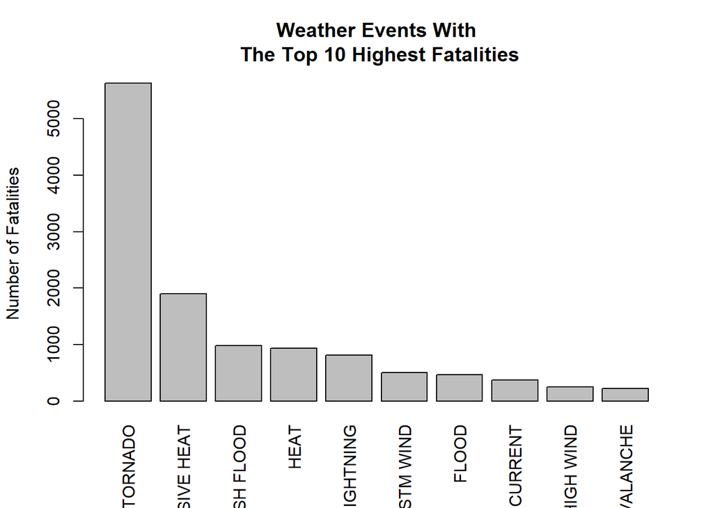

```r
p1 <- barplot(plot1$FATALITIES, las = 3, names.arg = plot1$EVTYPE,
        main = "Weather Events With\n The Top 10 Highest Fatalities", ylab = "Number of Fatalities", col = "grey")
```

### Top ten similar to bar chart, but displaying frequency of death

```r
formattable(head(formattable(merged_sorted), 10),
            align =c("l","l","c","c","r"),
            list(`Indicator Name` = formatter(
              "span", style = ~ style(color = "grey",font.weight = "bold")),
              `DEATH_FREQ` = color_bar(customRed)))
```

| EVTYPE | COUNT | FATALITIES | DEATH_FREQ |
| --- | --- | --- | --- |
| TORNADO | 60652 | 5633 | 0.09 |
| EXCESSIVE HEAT | 1678 | 1903 | 1.13 |
| FLASH FLOOD | 54277 | 978 | 0.02 |
| HEAT | 767 | 937 | 1.22 |
| LIGHTNING | 15754 | 816 | 0.05 |
| TSTM WIND | 219940 | 504 | 0.00 |
| FLOOD | 25326 | 470 | 0.02 |
| RIP CURRENT | 470 | 368 | 0.78 |
| HIGH WIND | 20212 | 248 | 0.01 |
| AVALANCHE | 386 | 224 | 0.58 |

## Across the United States, which types of events are caused the most injuries?

```r
injuries_by_type <- aggregate(INJURIES ~ EVTYPE, df, sum)
injuries_by_type_sorted <- injuries_by_type[order(-injuries_by_type$INJURIES),]
# merging occurences and fatalities into one data frame to get frequency of death by event type
merged_injuries <- merge(number_of_occurrences, injuries_by_type, by = "EVTYPE")
merged_injuries_sorted <- merged_injuries[order(-merged_injuries$INJURIES),]
merged_injuries_sorted$INJURY_FREQ <- (merged_injuries_sorted$INJURIES/merged_injuries_sorted$freq)
colnames(merged_injuries_sorted)[colnames(merged_injuries_sorted)=="freq"] <- "COUNT"
merged_injuries_sorted <- merged_injuries_sorted %>%
  mutate_if(is.numeric, round, digits = 2)
plot2 <- head(merged_injuries_sorted, 10)
```

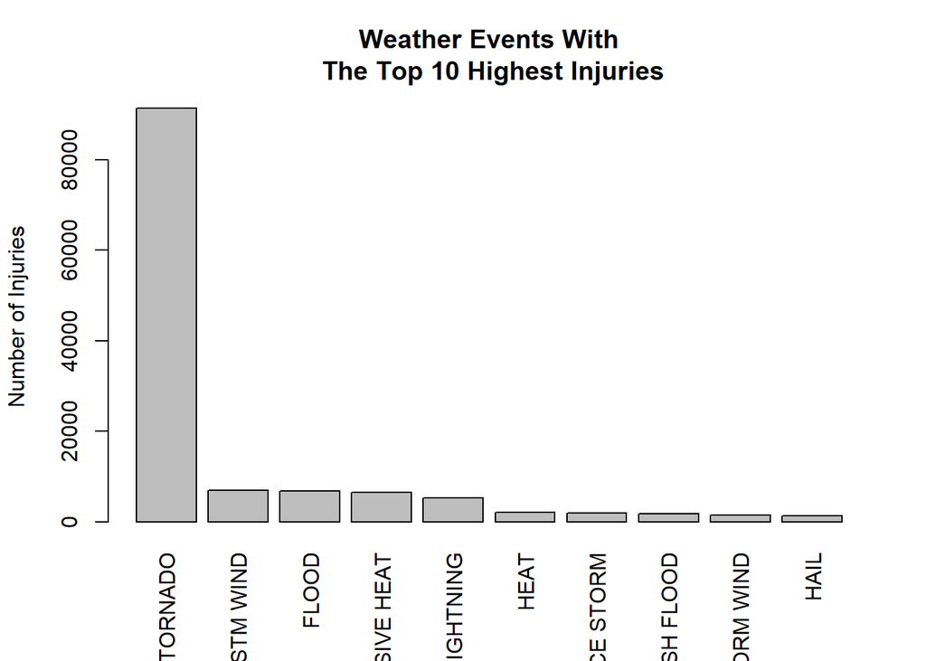

```r
p2 <- barplot(plot2$INJURIES, las = 3, names.arg = plot2$EVTYPE,
              main = "Weather Events With\n The Top 10 Highest Injuries", ylab = "Number of Injuries", col = "grey")
```

### Top ten similar to bar chart, but displaying frequency of injuries

```r
formattable(head(formattable(merged_injuries_sorted), 10),
            align =c("l","l","c","c","r"),
            list(`Indicator Name` = formatter(
              "span", style = ~ style(color = "grey",font.weight = "bold")),
              `INJURY_FREQ` = color_bar(customRed)))
```

| EVTYPE | COUNT | INJURIES | INJURY_FREQ |
| --- | --- | --- | --- |
| TORNADO | 60652 | 91346 | 1.51 |
| TSTM WIND | 219940 | 6957 | 0.03 |
| FLOOD | 25326 | 6789 | 0.27 |
| EXCESSIVE HEAT | 1678 | 6525 | 3.89 |
| LIGHTNING | 15754 | 5230 | 0.33 |
| HEAT | 767 | 2100 | 2.74 |
| ICE STORM | 2006 | 1975 | 0.98 |
| FLASH FLOOD | 54277 | 1777 | 0.03 |
| THUNDERSTORM WIND | 82563 | 1488 | 0.02 |
| HAIL | 288661 | 1361 | 0.00 |

## Across the United States, which types of events are caused the most property damage?

```r
property_damage_by_type <- aggregate(PROPDMG ~ EVTYPE, df, sum)
property_damage_merged <- merge(number_of_occurrences, property_damage_by_type, by = "EVTYPE")
property_damage_merged_sorted <- property_damage_merged[order(-property_damage_merged$PROPDMG),]
# Cost per event
property_damage_merged_sorted$COST_PER_EVENT <- (property_damage_merged$PROPDMG/property_damage_merged$freq)
colnames(property_damage_merged_sorted)[colnames(property_damage_merged_sorted)=="freq"] <- "COUNT"
plot3 <- head(property_damage_merged_sorted, 10)
```

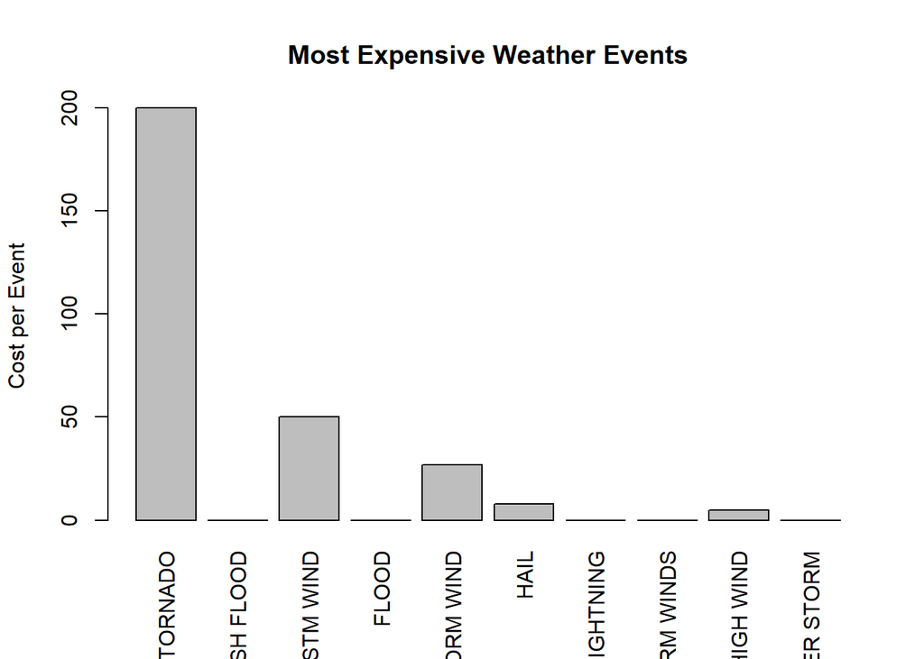

```r
p3 <- barplot(plot3$COST_PER_EVENT, las = 3, names.arg = plot3$EVTYPE,
              main = "Most Expensive Weather Events", ylab = "Cost per Event", col = "grey")
```

### Top ten similar to bar chart, but displaying cost per event

```r
row.names(property_damage_merged_sorted) <- NULL
formattable(head(formattable(property_damage_merged_sorted), 10),
            align =c("l","l","c","c","r"),
            list(`Indicator Name` = formatter(
              "span", style = ~ style(color = "grey",font.weight = "bold")),
              `COST_PER_EVENT` = color_bar(customRed)))
```

| EVTYPE | COUNT | PROPDMG | COST_PER_EVENT |
| --- | --- | --- | --- |
| TORNADO | 60652 | 3212258.2 | 200 |
| FLASH FLOOD | 54277 | 1420124.6 | 0 |
| TSTM WIND | 219940 | 1335965.6 | 50 |
| FLOOD | 25326 | 899938.5 | 0 |
| THUNDERSTORM WIND | 82563 | 876844.2 | 27 |
| HAIL | 288661 | 688693.4 | 8 |
| LIGHTNING | 15754 | 603351.8 | 0 |
| THUNDERSTORM WINDS | 20843 | 446293.2 | 0 |
| HIGH WIND | 20212 | 324731.6 | 5 |
| WINTER STORM | 11433 | 132720.6 | 0 |

## Across the United States, which types of events are caused the most crop damage?

```r
crop_damage_by_type <- aggregate(CROPDMG ~ EVTYPE, df, sum)
crop_damage_by_type_merged <- merge(number_of_occurrences, crop_damage_by_type, by = "EVTYPE")
crop_damage_by_type_merged_sorted <- crop_damage_by_type_merged[order(-crop_damage_by_type_merged$CROPDMG),]
# Crop damage per event
crop_damage_by_type_merged_sorted$CROP_PER_EVENT <- (crop_damage_by_type_merged_sorted$CROPDMG/crop_damage_by_type_merged_sorted$freq)
colnames(crop_damage_by_type_merged_sorted)[colnames(crop_damage_by_type_merged_sorted)=="freq"] <- "COUNT"
plot4 <- head(crop_damage_by_type_merged_sorted, 10)
```

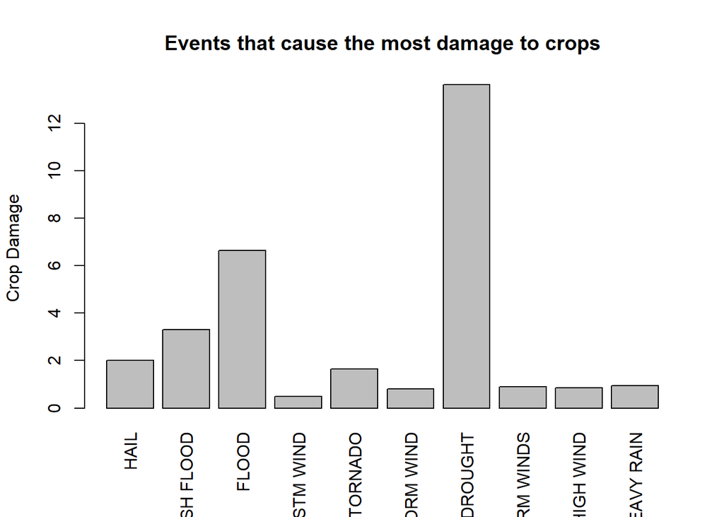

```r
p4 <- barplot(plot4$CROP_PER_EVENT, las = 3, names.arg = plot4$EVTYPE,
               main = "Events that cause the most damage to crops", ylab = "Crop Damage", col = "grey")
```

### Top ten similar to bar chart, but displaying crop damage per event

```r
row.names(crop_damage_by_type_merged_sorted) <- NULL
formattable(head(formattable(crop_damage_by_type_merged_sorted), 10),
            align =c("l","l","c","c","c"),
            list(`Indicator Name` = formatter(
              "span", style = ~ style(color = "grey",font.weight = "bold")),
              `CROP_PER_EVENT` = color_bar(customRed)))
```

| EVTYPE | COUNT | CROPDMG | CROP_PER_EVENT |
| --- | --- | --- | --- |
| HAIL | 288661 | 579596.28 | 2.0078787 |
| FLASH FLOOD | 54277 | 179200.46 | 3.3015911 |
| FLOOD | 25326 | 168037.88 | 6.6349949 |
| TSTM WIND | 219940 | 109202.60 | 0.4965109 |
| TORNADO | 60652 | 100018.52 | 1.6490556 |
| THUNDERSTORM WIND | 82563 | 66791.45 | 0.8089756 |
| DROUGHT | 2488 | 33898.62 | 13.6248473 |
| THUNDERSTORM WINDS | 20843 | 18684.93 | 0.8964607 |
| HIGH WIND | 20212 | 17283.21 | 0.8550965 |
| HEAVY RAIN | 11723 | 11122.80 | 0.9488015 |